# Early Stage Heart Disease Detection

Statistical Inference and Learning Project

Khushbu Mahendra Patil

# **SIL-Project: Early Stage Heart Disease Detection**

#### Date: 2024-01-18

## **Introduction**

Medical dictation has traditionally been a high-maintenance sector in terms of time, accuracy, and expense. Humans are fallible and capable of making mistakes. Cases of cardiovascular illness are increasing at an alarming rate, which is highly concerning. The human mind cannot comprehend too much estimation in order to point out any forecast based on several aspects, and so may deliver wrong feedback multiple times, putting the patient’s life at danger. Data mining has shown to be quite useful in projecting various situations in a variety of sectors. Several models have been created using data mining and deep learning in tandem to foresee certain scenarios for us to operate on.

Similarly, the UCI dataset for Heart Disease Research was utilized to build a model that forecasts heart illness with the best accuracy using Machine learning models. Every year, around 1.5 million individuals die as a result of cardiovascular disease (CVD). It is responsible for about 31% of all fatalities worldwide. According to World Health Organization (WHO) figures, low- and middle-income countries account for 82 percent of worldwide premature mortality, with cardiovascular disease (CVD) accounting for 37 percent due to the late and incorrect prognosis of heart disease. While these illnesses are treatable, early prognosis and risk assessment of patients is critical to reducing the substantial mortality risks they represent. Common cardiovascular illnesses include coronary heart disease, Cardiomyopathy, hypertensive heart disease, heart failure, and others. Certain symptoms and lifestyle choices increase the risk of cardiovascular disease. Such patterns can also be used to predict cardiac disease.

Machine Learning plays an essential role in the prediction of cardiac disease. Terms used in computer intelligence can be utilized to characterize the correlations between patient variables such as heart rate, obesity, and other disorders. Machine learning plays an important role in the medical field. It uses enormous databases and historical medical history to forecast sickness. Machine learning and approaches are being utilized to predict cardiac illnesses based on the patient’s risk factors and clinical history. Several factors, such as heart rate, age, blood pressure (BP), obesity, sex, and others, are used as parameters to compare and predict heart disease.

To describe the nature of our data, it is first studied using various Exploratory Data Analysis (EDA) approaches, then some standardization is applied to fix the data in the case of certain empty data cell problems. Under EDA approaches, the data is once again evaluated in order to learn various types and samples of data. The data is then sliced and split into two portions in order to train and test models.

### The Dataset

12 variables from the dataset are:

1. Age: the age of the patient in years
2. Sex: the sex of the patient (1 = male; 0 = female)
3. Chest pain type (cp): the type of chest pain experienced by the patient (1 = typical angina, 2 = atypical angina, 3 = non-anginal pain, 4 = asymptomatic)
4. Resting blood pressure (trestbps): the patient’s resting blood pressure (in mm Hg) upon admission to the clinic
5. Serum cholesterol (chol): the patient’s serum cholesterol level (in mg/dL)
6. Fasting blood sugar (fbs): whether the patient’s fasting blood sugar level is greater than 120 mg/dL (1 = true; 0 = false)
7. Resting electrocardiographic results (restecg): results of the resting electrocardiogram (0 = normal, 1 = having ST-T wave abnormality, 2 = showing probable or definite left ventricular hypertrophy)
8. Maximum heart rate achieved (thalach): the patient’s maximum heart rate achieved during exercise
9. Exercise induced angina (exang): whether the patient experienced angina during exercise (1 = yes; 0 = no)
10. ST depression induced by exercise relative to rest (oldpeak): the amount of ST depression induced by exercise relative to rest
11. Slope of the peak exercise ST segment (slope): the slope of the peak exercise ST segment (1 = upsloping, 2 = flat, 3 = downsloping)

### Target variable

12. Diagnosis of heart disease (target): the presence or absence of heart disease (0 = absence, 1 = presence)

## Exploratory Data Analysis

Exploratory data analysis (EDA) is a method of examining and comprehending data by displaying and summarizing its key features. EDA’s goal is to obtain insights into data and uncover patterns, correlations, and anomalies that might assist influence future analysis or decision-making.

The basic purpose of EDA is to investigate and comprehend the structure of data, including its distribution, range, and variability. This includes assessing individual variables and their links to one another, as well as the general shape and organization of the data collection.

Exploratory data analysis is a critical initial stage in every data analysis project because it lays the groundwork for later research and ensures that our results are correct and dependable.

#### **Reading the Data-set**

```r
heart_disease <- read.csv("C:/Users/khush/OneDrive/Desktop/RProject - KW/heart_disease/heart_statlog_cleveland_hungary.csv")
```

```r
# install.packages("tidyverse")
# install.packages("corrplot")
# install.packages("ggplot2")
# install.packages("dplyr")
# install.packages("glmnet")
# install.packages("mgcv")
# install.packages("caret")
# install.packages("car")
# install.packages("Metrics")
# install.packages("MASS")
```

#### **Loading the necessary libraries**

```r
library(tidyverse)
```

```r
library(corrplot)
library(ggplot2)
library(dplyr)
library(glmnet)
library(mgcv)
library(caret)
library(car)
library(Metrics)
library(performance)
library(pROC)
library(MASS)
```

Let’s understand our data

```r
#checking the column structure
str(heart_disease)
```

```
## 'data.frame':    1025 obs. of  12 variables:
##  $ age                : int  52 53 70 61 62 58 58 55 46 54 ...
##  $ sex                : int  1 1 1 1 0 0 1 1 1 1 ...
##  $ Chest.pain.type    : int  0 0 0 0 0 0 0 0 0 0 ...
##  $ resting.bp.s       : int  125 140 145 148 138 100 114 160 120 122 ...
##  $ cholesterol        : int  212 203 174 203 294 248 318 289 249 286 ...
##  $ fasting.blood.sugar: int  0 1 0 0 1 0 0 0 0 0 ...
##  $ resting.ecg        : int  1 0 1 1 1 0 2 0 0 0 ...
##  $ max.heart.rate     : int  168 155 125 161 106 122 140 145 144 116 ...
##  $ exercise.angina    : int  0 1 1 0 0 0 0 1 0 1 ...
##  $ oldpeak            : num  1 3.1 2.6 0 1.9 1 4.4 0.8 0.8 3.2 ...
##  $ ST.slope           : int  2 0 0 2 1 1 0 1 2 1 ...
##  $ target             : int  0 0 0 0 0 1 0 0 0 0 ...
```

```r
#checking the summary of the dataset
summary(heart_disease)
```

```
##       age             sex         Chest.pain.type   resting.bp.s
##  Min.   :29.00   Min.   :0.0000   Min.   :0.0000   Min.   : 94.0
##  1st Qu.:48.00   1st Qu.:0.0000   1st Qu.:0.0000   1st Qu.:120.0
##  Median :56.00   Median :1.0000   Median :1.0000   Median :130.0
##  Mean   :54.43   Mean   :0.6956   Mean   :0.9424   Mean   :131.6
##  3rd Qu.:61.00   3rd Qu.:1.0000   3rd Qu.:2.0000   3rd Qu.:140.0
##  Max.   :77.00   Max.   :1.0000   Max.   :3.0000   Max.   :200.0
##   cholesterol  fasting.blood.sugar  resting.ecg     max.heart.rate
##  Min.   :126   Min.   :0.0000      Min.   :0.0000   Min.   : 71.0
##  1st Qu.:211   1st Qu.:0.0000      1st Qu.:0.0000   1st Qu.:132.0
##  Median :240   Median :0.0000      Median :1.0000   Median :152.0
##  Mean   :246   Mean   :0.1493      Mean   :0.5298   Mean   :149.1
##  3rd Qu.:275   3rd Qu.:0.0000      3rd Qu.:1.0000   3rd Qu.:166.0
##  Max.   :564   Max.   :1.0000      Max.   :2.0000   Max.   :202.0
##  exercise.angina     oldpeak         ST.slope         target
##  Min.   :0.0000   Min.   :0.000   Min.   :0.000   Min.   :0.0000
##  1st Qu.:0.0000   1st Qu.:0.000   1st Qu.:1.000   1st Qu.:0.0000
##  Median :0.0000   Median :0.800   Median :1.000   Median :1.0000
##  Mean   :0.3366   Mean   :1.072   Mean   :1.385   Mean   :0.5132
##  3rd Qu.:1.0000   3rd Qu.:1.800   3rd Qu.:2.000   3rd Qu.:1.0000
##  Max.   :1.0000   Max.   :6.200   Max.   :2.000   Max.   :1.0000
```

```r
#converting the Categorical Data from Numeric to Factors
heart_disease$sex<-factor(heart_disease$sex,levels =c(0,1),labels = c("female","male"))
str(heart_disease)
```

```
## 'data.frame':    1025 obs. of  12 variables:
##  $ age                : int  52 53 70 61 62 58 58 55 46 54 ...
##  $ sex                : Factor w/ 2 levels "female","male": 2 2 2 2 1 1 2 2 2 2 ...
##  $ Chest.pain.type    : int  0 0 0 0 0 0 0 0 0 0 ...
##  $ resting.bp.s       : int  125 140 145 148 138 100 114 160 120 122 ...
##  $ cholesterol        : int  212 203 174 203 294 248 318 289 249 286 ...
##  $ fasting.blood.sugar: int  0 1 0 0 1 0 0 0 0 0 ...
##  $ resting.ecg        : int  1 0 1 1 1 0 2 0 0 0 ...
##  $ max.heart.rate     : int  168 155 125 161 106 122 140 145 144 116 ...
##  $ exercise.angina    : int  0 1 1 0 0 0 0 1 0 1 ...
##  $ oldpeak            : num  1 3.1 2.6 0 1.9 1 4.4 0.8 0.8 3.2 ...
##  $ ST.slope           : int  2 0 0 2 1 1 0 1 2 1 ...
##  $ target             : int  0 0 0 0 0 1 0 0 0 0 ...
```

```r
#converting the Categorical Data from Numeric to Factors
heart_disease$fasting.blood.sugar<-as.factor(heart_disease$fasting.blood.sugar)
str(heart_disease)
```

```
## 'data.frame':    1025 obs. of  12 variables:
##  $ age                : int  52 53 70 61 62 58 58 55 46 54 ...
##  $ sex                : Factor w/ 2 levels "female","male": 2 2 2 2 1 1 2 2 2 2 ...
##  $ Chest.pain.type    : int  0 0 0 0 0 0 0 0 0 0 ...
##  $ resting.bp.s       : int  125 140 145 148 138 100 114 160 120 122 ...
##  $ cholesterol        : int  212 203 174 203 294 248 318 289 249 286 ...
##  $ fasting.blood.sugar: Factor w/ 2 levels "0","1": 1 2 1 1 2 1 1 1 1 1 ...
##  $ resting.ecg        : int  1 0 1 1 1 0 2 0 0 0 ...
##  $ max.heart.rate     : int  168 155 125 161 106 122 140 145 144 116 ...
##  $ exercise.angina    : int  0 1 1 0 0 0 0 1 0 1 ...
##  $ oldpeak            : num  1 3.1 2.6 0 1.9 1 4.4 0.8 0.8 3.2 ...
##  $ ST.slope           : int  2 0 0 2 1 1 0 1 2 1 ...
##  $ target             : int  0 0 0 0 0 1 0 0 0 0 ...
```

```r
#converting the Categorical Data from Numeric to Factors
heart_disease$Chest.pain.type <- as.factor(heart_disease$Chest.pain.type)

# Define the labels for the levels
chest_pain_labels <- c(' Typical Angina ', ' Atypical Angina ', ' Non-anginal Pain ', ' Asymptomatic ')

# Set the levels of the factor variable
levels(heart_disease$Chest.pain.type) <- chest_pain_labels

# Check the structure of the data frame
str(heart_disease)
```

```
## 'data.frame':    1025 obs. of  12 variables:
##  $ age                : int  52 53 70 61 62 58 58 55 46 54 ...
##  $ sex                : Factor w/ 2 levels "female","male": 2 2 2 2 1 1 2 2 2 2 ...
##  $ Chest.pain.type    : Factor w/ 4 levels " Typical Angina ",..: 1 1 1 1 1 1 1 1 1 1 ...
##  $ resting.bp.s       : int  125 140 145 148 138 100 114 160 120 122 ...
##  $ cholesterol        : int  212 203 174 203 294 248 318 289 249 286 ...
##  $ fasting.blood.sugar: Factor w/ 2 levels "0","1": 1 2 1 1 2 1 1 1 1 1 ...
##  $ resting.ecg        : int  1 0 1 1 1 0 2 0 0 0 ...
##  $ max.heart.rate     : int  168 155 125 161 106 122 140 145 144 116 ...
##  $ exercise.angina    : int  0 1 1 0 0 0 0 1 0 1 ...
##  $ oldpeak            : num  1 3.1 2.6 0 1.9 1 4.4 0.8 0.8 3.2 ...
##  $ ST.slope           : int  2 0 0 2 1 1 0 1 2 1 ...
##  $ target             : int  0 0 0 0 0 1 0 0 0 0 ...
```

```r
#converting the Categorical Data from Numeric to Factors
heart_disease$resting.ecg<-as.factor(heart_disease$resting.ecg )
str(heart_disease)
```

```
## 'data.frame':    1025 obs. of  12 variables:
##  $ age                : int  52 53 70 61 62 58 58 55 46 54 ...
##  $ sex                : Factor w/ 2 levels "female","male": 2 2 2 2 1 1 2 2 2 2 ...
##  $ Chest.pain.type    : Factor w/ 4 levels " Typical Angina ",..: 1 1 1 1 1 1 1 1 1 1 ...
##  $ resting.bp.s       : int  125 140 145 148 138 100 114 160 120 122 ...
##  $ cholesterol        : int  212 203 174 203 294 248 318 289 249 286 ...
##  $ fasting.blood.sugar: Factor w/ 2 levels "0","1": 1 2 1 1 2 1 1 1 1 1 ...
##  $ resting.ecg        : Factor w/ 3 levels "0","1","2": 2 1 2 2 2 1 3 1 1 1 ...
##  $ max.heart.rate     : int  168 155 125 161 106 122 140 145 144 116 ...
##  $ exercise.angina    : int  0 1 1 0 0 0 0 1 0 1 ...
##  $ oldpeak            : num  1 3.1 2.6 0 1.9 1 4.4 0.8 0.8 3.2 ...
##  $ ST.slope           : int  2 0 0 2 1 1 0 1 2 1 ...
##  $ target             : int  0 0 0 0 0 1 0 0 0 0 ...
```

```r
#converting the Categorical Data from Numeric to Factors
heart_disease$exercise.angina<-as.factor(heart_disease$exercise.angina)
str(heart_disease)
```

```
## 'data.frame':    1025 obs. of  12 variables:
##  $ age                : int  52 53 70 61 62 58 58 55 46 54 ...
##  $ sex                : Factor w/ 2 levels "female","male": 2 2 2 2 1 1 2 2 2 2 ...
##  $ Chest.pain.type    : Factor w/ 4 levels " Typical Angina ",..: 1 1 1 1 1 1 1 1 1 1 ...
##  $ resting.bp.s       : int  125 140 145 148 138 100 114 160 120 122 ...
##  $ cholesterol        : int  212 203 174 203 294 248 318 289 249 286 ...
##  $ fasting.blood.sugar: Factor w/ 2 levels "0","1": 1 2 1 1 2 1 1 1 1 1 ...
##  $ resting.ecg        : Factor w/ 3 levels "0","1","2": 2 1 2 2 2 1 3 1 1 1 ...
##  $ max.heart.rate     : int  168 155 125 161 106 122 140 145 144 116 ...
##  $ exercise.angina    : Factor w/ 2 levels "0","1": 1 2 2 1 1 1 1 2 1 2 ...
##  $ oldpeak            : num  1 3.1 2.6 0 1.9 1 4.4 0.8 0.8 3.2 ...
##  $ ST.slope           : int  2 0 0 2 1 1 0 1 2 1 ...
##  $ target             : int  0 0 0 0 0 1 0 0 0 0 ...
```

```r
#converting the Categorical Data from Numeric to Factors
heart_disease$ST.slope<-as.factor(heart_disease$ST.slope)
str(heart_disease)
```

```
## 'data.frame':    1025 obs. of  12 variables:
##  $ age                : int  52 53 70 61 62 58 58 55 46 54 ...
##  $ sex                : Factor w/ 2 levels "female","male": 2 2 2 2 1 1 2 2 2 2 ...
##  $ Chest.pain.type    : Factor w/ 4 levels " Typical Angina ",..: 1 1 1 1 1 1 1 1 1 1 ...
##  $ resting.bp.s       : int  125 140 145 148 138 100 114 160 120 122 ...
##  $ cholesterol        : int  212 203 174 203 294 248 318 289 249 286 ...
##  $ fasting.blood.sugar: Factor w/ 2 levels "0","1": 1 2 1 1 2 1 1 1 1 1 ...
##  $ resting.ecg        : Factor w/ 3 levels "0","1","2": 2 1 2 2 2 1 3 1 1 1 ...
##  $ max.heart.rate     : int  168 155 125 161 106 122 140 145 144 116 ...
##  $ exercise.angina    : Factor w/ 2 levels "0","1": 1 2 2 1 1 1 1 2 1 2 ...
##  $ oldpeak            : num  1 3.1 2.6 0 1.9 1 4.4 0.8 0.8 3.2 ...
##  $ ST.slope           : Factor w/ 3 levels "0","1","2": 3 1 1 3 2 2 1 2 3 2 ...
##  $ target             : int  0 0 0 0 0 1 0 0 0 0 ...
```

```r
#converting the Categorical Data from Numeric to Factors
heart_disease$target<-as.factor(heart_disease$target)
str(heart_disease)
```

```
## 'data.frame':    1025 obs. of  12 variables:
##  $ age                : int  52 53 70 61 62 58 58 55 46 54 ...
##  $ sex                : Factor w/ 2 levels "female","male": 2 2 2 2 1 1 2 2 2 2 ...
##  $ Chest.pain.type    : Factor w/ 4 levels " Typical Angina ",..: 1 1 1 1 1 1 1 1 1 1 ...
##  $ resting.bp.s       : int  125 140 145 148 138 100 114 160 120 122 ...
##  $ cholesterol        : int  212 203 174 203 294 248 318 289 249 286 ...
##  $ fasting.blood.sugar: Factor w/ 2 levels "0","1": 1 2 1 1 2 1 1 1 1 1 ...
##  $ resting.ecg        : Factor w/ 3 levels "0","1","2": 2 1 2 2 2 1 3 1 1 1 ...
##  $ max.heart.rate     : int  168 155 125 161 106 122 140 145 144 116 ...
##  $ exercise.angina    : Factor w/ 2 levels "0","1": 1 2 2 1 1 1 1 2 1 2 ...
##  $ oldpeak            : num  1 3.1 2.6 0 1.9 1 4.4 0.8 0.8 3.2 ...
##  $ ST.slope           : Factor w/ 3 levels "0","1","2": 3 1 1 3 2 2 1 2 3 2 ...
##  $ target             : Factor w/ 2 levels "0","1": 1 1 1 1 1 2 1 1 1 1 ...
```

```r
#checking for Nulls
colSums(is.na(heart_disease))
```

```
##                 age                 sex     Chest.pain.type        resting.bp.s
##                   0                   0                   0                   0
##         cholesterol fasting.blood.sugar         resting.ecg      max.heart.rate
##                   0                   0                   0                   0
##     exercise.angina             oldpeak            ST.slope              target
##                   0                   0                   0                   0
```

```r
#checking the dimensions
dim(heart_disease)
```

```
## [1] 1025   12
```

```r
head(heart_disease)
```

```
##   age    sex  Chest.pain.type resting.bp.s cholesterol fasting.blood.sugar
## 1  52   male  Typical Angina           125         212                   0
## 2  53   male  Typical Angina           140         203                   1
## 3  70   male  Typical Angina           145         174                   0
## 4  61   male  Typical Angina           148         203                   0
## 5  62 female  Typical Angina           138         294                   1
## 6  58 female  Typical Angina           100         248                   0
##   resting.ecg max.heart.rate exercise.angina oldpeak ST.slope target
## 1           1            168               0     1.0        2      0
## 2           0            155               1     3.1        0      0
## 3           1            125               1     2.6        0      0
## 4           1            161               0     0.0        2      0
## 5           1            106               0     1.9        1      0
## 6           0            122               0     1.0        1      1
```

```r
#Descriptive statistics
mean <- mean(heart_disease$age)
mean
```

```
## [1] 54.43415
```

```r
median <- median(heart_disease$age)
median
```

```
## [1] 56
```

Understanding the correlation between different variables is very helpful in understanding the dataset

```r
#correlation matrix
numeric_data <- heart_disease[, sapply(heart_disease, is.numeric)]

# Correlation matrix for numeric columns
cor_matrix <- cor(numeric_data)
round(cor_matrix, digits = 2)
```

```
##                  age resting.bp.s cholesterol max.heart.rate oldpeak
## age             1.00         0.27        0.22          -0.39    0.21
## resting.bp.s    0.27         1.00        0.13          -0.04    0.19
## cholesterol     0.22         0.13        1.00          -0.02    0.06
## max.heart.rate -0.39        -0.04       -0.02           1.00   -0.35
## oldpeak         0.21         0.19        0.06          -0.35    1.00
```

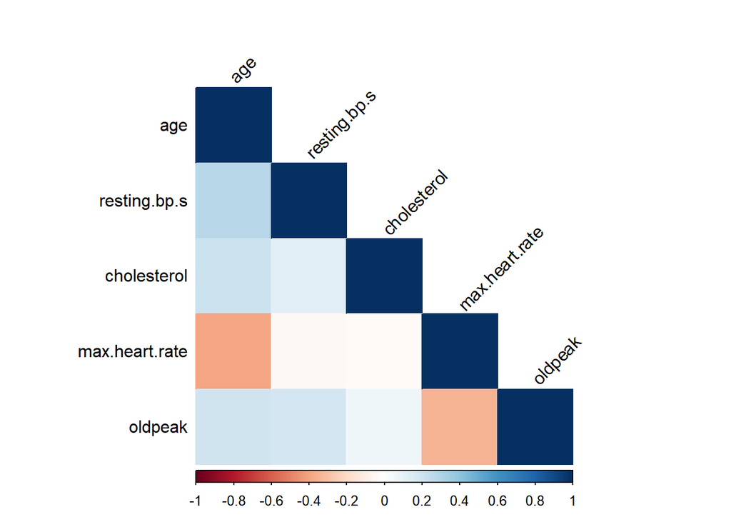

```r
corrplot(cor_matrix, method = "color", type = "lower", tl.col = "black", tl.srt = 45)
```

A correlation heatmap is a graphical representation of the correlation matrix, which displays the pairwise correlations between distinct variables in a dataset. Here are some ways to help you comprehend a correlation heatmap:

**Determine the strength of correlation:** The hue of the heatmap indicates the intensity of the association. A deeper hue suggests a higher association, whereas a lighter tint indicates a lesser correlation. If two variables have a positive correlation, then if one variable rises, so will the other. If two variables have a negative correlation, then when one one grows, the other variable decreases.

#### Data Exploration

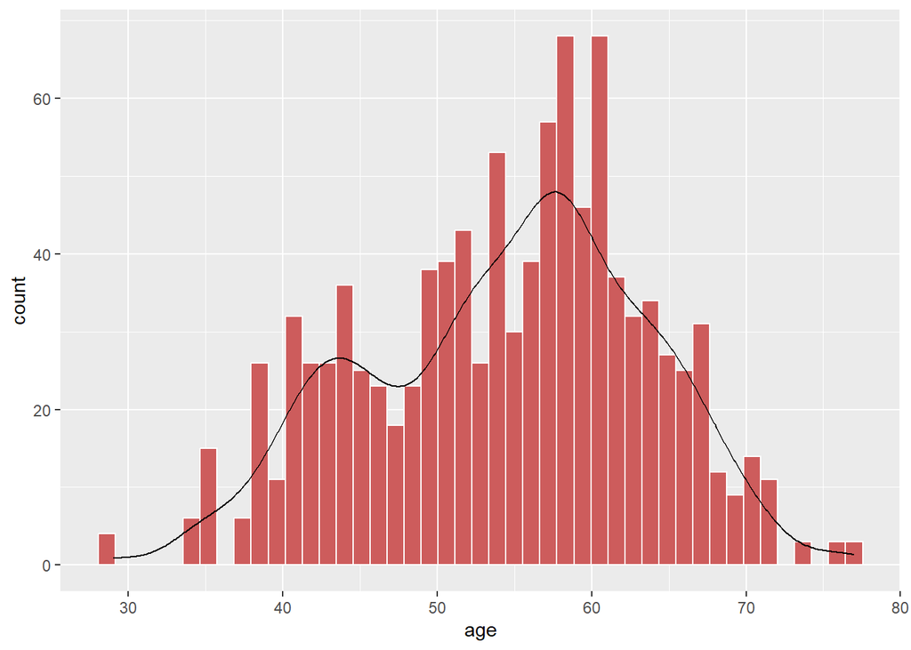

```r
#Checking the distribution of Age
ggplot(heart_disease,aes(x=age))+
  geom_histogram(binwidth=1.1, color="white", fill = "indianred")+
  geom_density(aes(y= after_stat(count)))
```

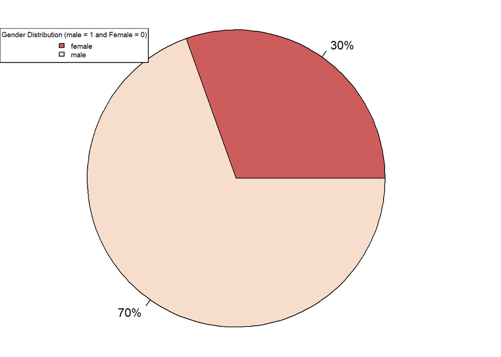

```r
#Pie-Chart for Gender distribution
clr=c("indianred","#F6DDCC")
par(mar=c(2,0,2,2))
pie(table(heart_disease$sex),
labels = paste0(round(table(heart_disease$sex) / nrow(heart_disease) * 100), "%"),
radius=1.07, col=clr)
legend("topleft", names(table(heart_disease$sex)), title = "Gender Distribution (male = 1 and Female = 0)", cex = 0.60, fill = clr)
```

Above pie-chart shows that the percentage of **Female is 30%** whereas **Male percentage is 70%** which is higher than the percentage of female patients in the dataset.

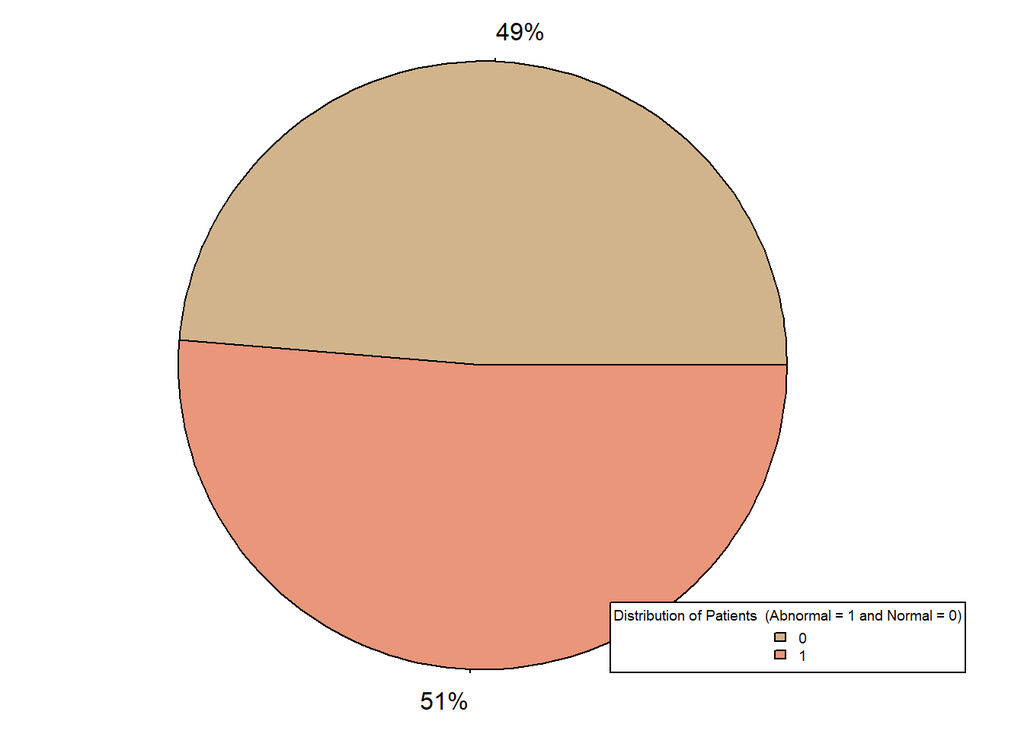

```r
#Pie-Chart for Distribution of Patients
clr=c("tan","darksalmon")
par(mar=c(2,0,2,2))
pie(table(heart_disease$target),
labels = paste0(round(table(heart_disease$target) / nrow(heart_disease) * 100), "%"),
radius=1.07, col=clr)
legend("bottomright", names(table(heart_disease$target)), title = "Distribution of Patients  (Abnormal = 1 and Normal = 0)", cex = 0.60, fill = clr)
```

Pie-chart shown above depicts that in our dataset, we have **51% are Heart Patients** and **49% are Normal Patients**. This information is interesting to see that based on our current dataset there is a large percentage of people that is diagnosed with Heart disease, which is alarming.

```r
#filtering the data of normal and abnormal patients
normal <- filter(heart_disease, target == 0)
abnormal <- filter(heart_disease, target == 1)
```

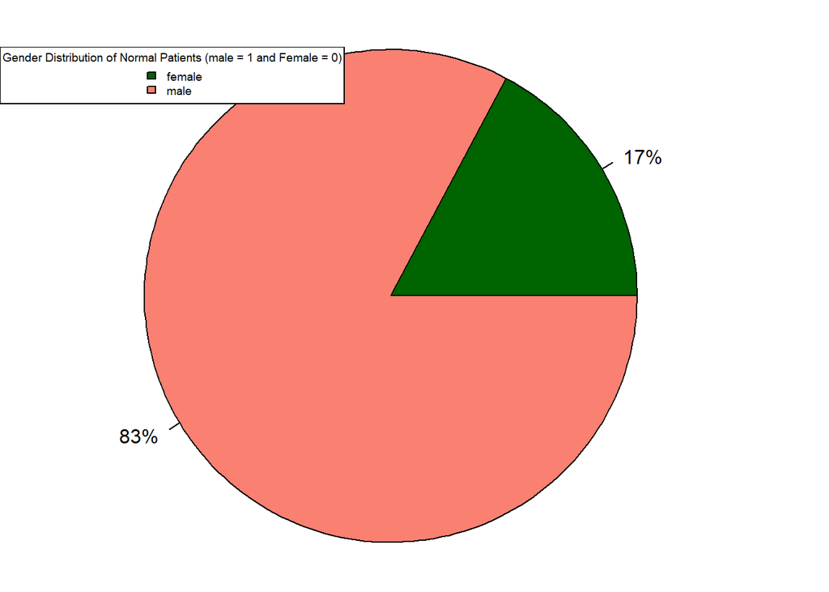

```r
#Pie-Chart for Gender distribution of normal patients
clr=c("darkgreen","salmon")
par(mar=c(2,0,2,2))
pie(table(normal$sex),
labels = paste0(round(table(normal$sex) / nrow(normal) * 100), "%"),
radius=1.07, col=clr)
legend("topleft", names(table(normal$sex)), title = "Gender Distribution of Normal Patients (male = 1 and Female = 0)", cex = 0.60, fill = clr)
```

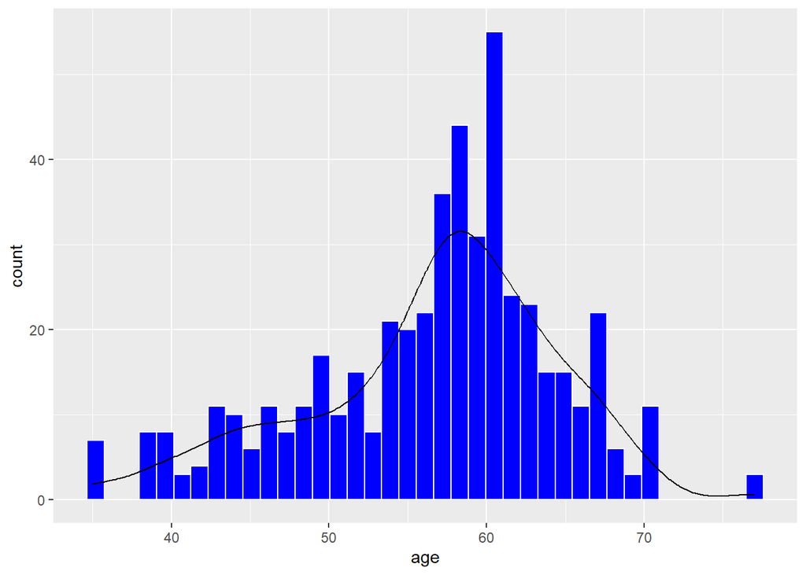

```r
#Checking the distribution of Age of normal patients
ggplot(normal,aes(x=age))+
  geom_histogram(binwidth=1.1, color="white" , fill = "blue")+
  geom_density(aes(y= after_stat(count)))
```

If we look at this plot, we can see that the average age is around 55 to 65

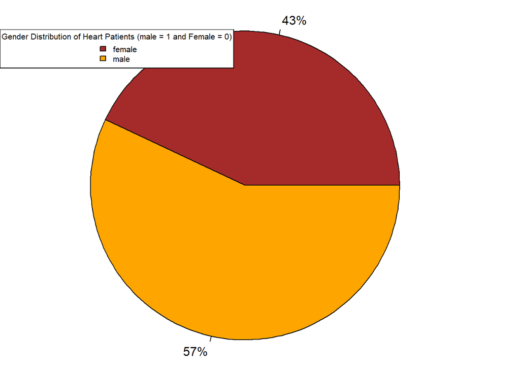

```r
#Pie-Chart for Gender distribution
clr=c("brown","orange")
par(mar=c(2,0,2,2))
pie(table(abnormal$sex),
labels = paste0(round(table(abnormal$sex) / nrow(abnormal) * 100), "%"),
radius=1.07, col=clr)
legend("topleft", names(table(abnormal$sex)), title = "Gender Distribution of Heart Patients (male = 1 and Female = 0)", cex = 0.65, fill = clr)
```

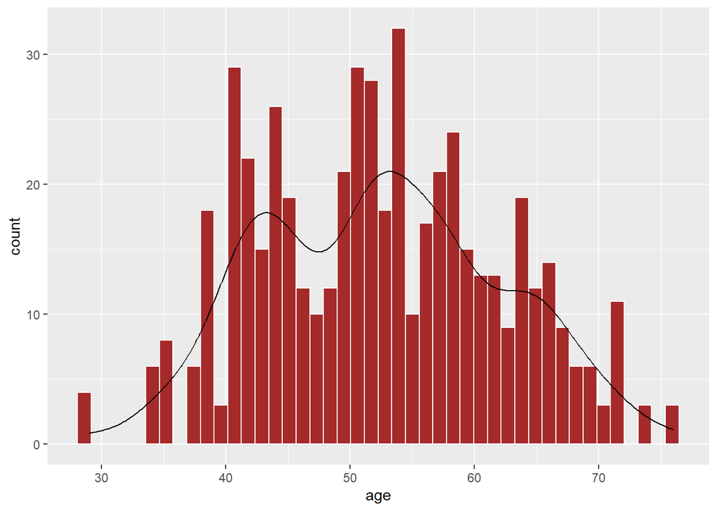

```r
#Checking the distribution of Age of Heart patients
ggplot(abnormal,aes(x=age))+
  geom_histogram(binwidth=1.1, color="white", fill = "brown")+
  geom_density(aes(y= after_stat(count)))
```

Here we can observe that the mean age of the heart disease patients is around 42 to 57 years.

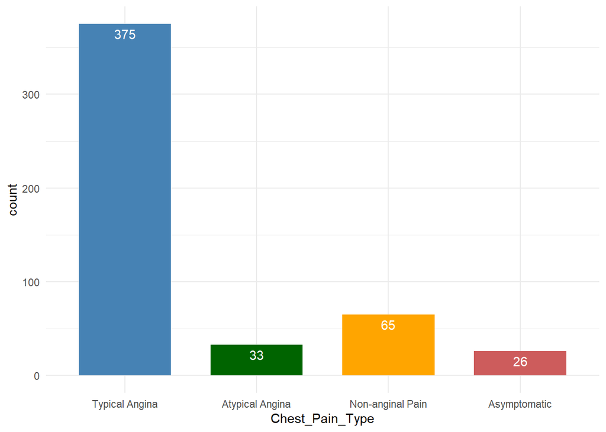

```r
#Checking different type of chest pains in Normal Patients
Chest_Pain_Type <- factor(normal$Chest.pain.type)
ggplot(normal, aes(x=Chest_Pain_Type))+
  geom_bar(stat="count", width=0.7, fill=c("steelblue", "darkgreen","orange", "indianred")  )+
  scale_x_discrete(labels=c('Typical Angina','Atypical Angina','Non-anginal Pain','Asymptomatic'))+
   geom_text(aes(label = after_stat(count)), stat = "count", vjust = 1.5, colour = "white")+
  theme_minimal()
```

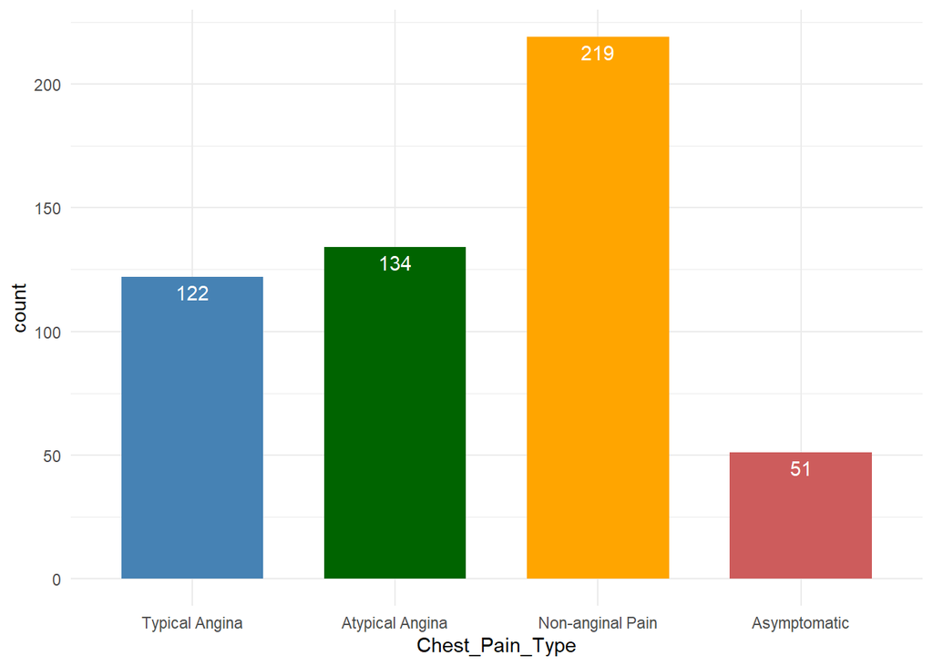

```r
#Checking different type of chest pains in Heart Patients
Chest_Pain_Type <- factor(abnormal$Chest.pain.type)
ggplot(abnormal, aes(x=Chest_Pain_Type))+
  geom_bar(stat="count", width=0.7, fill=c("steelblue", "darkgreen","orange", "indianred") )+
  scale_x_discrete(labels=c('Typical Angina','Atypical Angina','Non-anginal Pain','Asymptomatic'))+
  geom_text(aes(label = after_stat(count)), stat = "count", vjust = 1.5, colour = "white")+
  theme_minimal()
```

*Asymptomatic heart attacks*, also known as **silent heart attacks**, are a kind of heart attack that happens without any obvious symptoms. These sorts of heart attacks are more prevalent in older folks and diabetics, who may not experience usual chest pain or discomfort. Yet, just because there are no symptoms does not indicate that no harm is being done. Asymptomatic heart attacks can permanently damage the heart muscle and raise the risk of future heart issues. High blood pressure, high cholesterol, smoking, and a family history of heart disease are risk factors for asymptomatic heart attacks. Asymptomatic heart attacks can be treated with lifestyle modifications, drugs, and procedures such as angioplasty or stenting. Maintaining a healthy lifestyle, managing chronic diseases, and seeking regular medical treatment all help to lower the risk of asymptomatic heart attacks. If you believe you may have had an asymptomatic heart attack, speak with your doctor about your risk factors and treatment and preventative options [[1](https://www.mayoclinic.org/diseases-conditions/heart-attack/expert-answers/silent-heart-attack/faq-20057777#:~:text=A%20silent%20heart%20attack%20is,associated%20with%20a%20heart%20attack.)].

#### Electrocardiogram (ECG):

An electrocardiogram (ECG) is a medical test that records the electrical activity of the heart. It is a non-invasive test in which electrodes are placed on the chest, arms, and legs and then linked to a machine that captures the electrical impulses produced by the heart. The ECG is a visual picture of the electrical activity of the heart that can aid in the diagnosis of different cardiac problems such as arrhythmias, heart attacks, and heart failure. The examination is normally painless and takes only a few minutes to conduct. ECGs are routinely used in normal medical examinations as well as in emergency circumstances to monitor a patient’s cardiac function. ECG interpretation necessitates specific expertise, and the data are often examined by a healthcare practitioner such as a cardiologist [[2](https://www.nhs.uk/conditions/electrocardiogram/)].

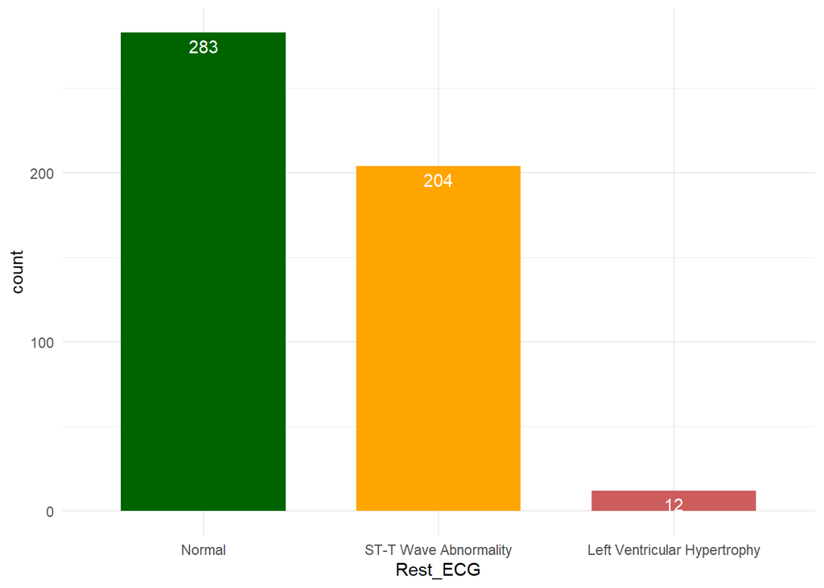

```r
#Checking the Rest ECG of Normal Patients
Rest_ECG <- factor(normal$resting.ecg)
ggplot(normal, aes(x=Rest_ECG))+
  geom_bar(stat="count", width=0.7, fill=c("darkgreen","orange", "indianred") )+
  scale_x_discrete(labels=c('Normal','ST-T Wave Abnormality','Left Ventricular Hypertrophy'))+
  geom_text(aes(label = after_stat(count)), stat = "count", vjust = 1.5, colour = "white")+
  theme_minimal()
```

From this plot it not surprising to see that almost 283 normal patients had normal ECG, but what interesting is that almost 12 patients’ ECG was concluded as left ventricular hypertrophy.

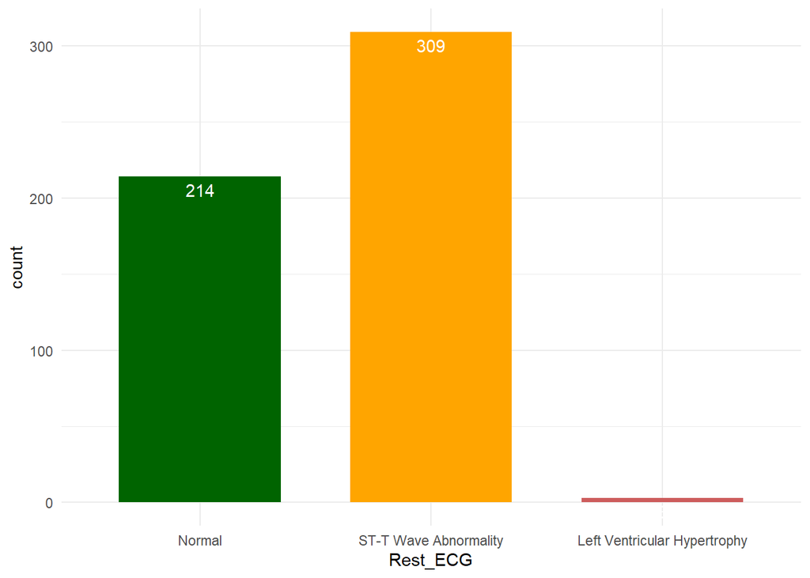

```r
#Checking the Rest ECG of Heart Patients
Rest_ECG <- factor(abnormal$resting.ecg)
ggplot(abnormal, aes(x=Rest_ECG))+
  geom_bar(stat="count", width=0.7, fill=c("darkgreen","orange", "indianred") )+
  scale_x_discrete(labels=c('Normal','ST-T Wave Abnormality','Left Ventricular Hypertrophy'))+
  geom_text(aes(label = after_stat(count)), stat = "count", vjust = 1.5, colour = "white")+
  theme_minimal()
```

From this plot of the ECGs of Heart patients, it is surprising to observe that almost 214 heart patients’ ECG was normal. Based on this information we can conclude that just abnormal ECG is not an indication of Heart Disease.

#### ST Segment Slope

The ST segment is a section of the ECG (electrocardiogram) that depicts the time between ventricular depolarization and repolarization. The ST segment is measured from the end of the QRS complex to the beginning of the T wave. The ST slope is the direction and angle of the ST segment in reference to the isoelectric line (the baseline) on the ECG.

The ST slope can be upsloping, downsloping, or level. A typical ST segment is generally flat and parallel to the isoelectric line. A large departure from the baseline ST segment might suggest an anomaly in the heart’s electrical conduction system and can be diagnostic of certain cardiac disorders such as myocardial ischemia (inadequate blood flow to the heart), myocardial infarction (heart attack), or pericarditis (inflammation of the lining of the heart).

Cardiologists carefully assess the ST segment slope to establish the underlying cause of any irregularities and to design a suitable treatment strategy. They may also utilize further diagnostic procedures, such as cardiac enzyme analysis or echocardiography, to confirm a diagnosis and track the course of the problem [[3](https://www.ncbi.nlm.nih.gov/books/NBK459364/)].

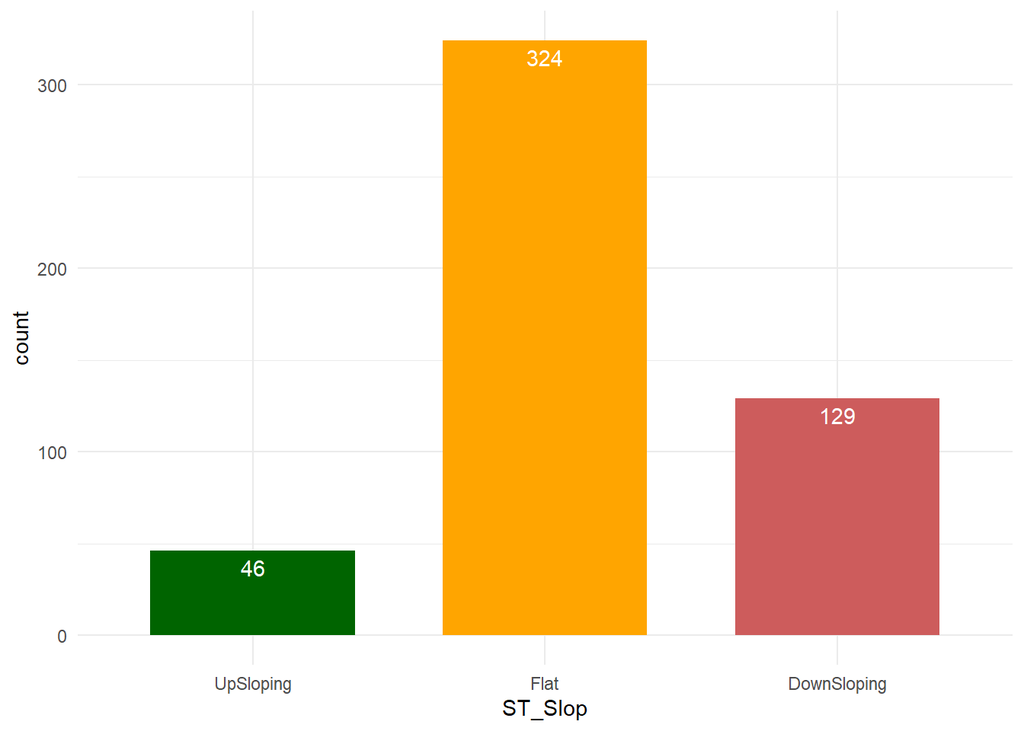

```r
#Checking the ST Slope of Normal Patients
ST_Slop <- factor(normal$ST.slope)
ggplot(normal, aes(x=ST_Slop))+
  geom_bar(stat="count", width=0.7, fill=c("darkgreen","orange", "indianred") )+
  scale_x_discrete(labels=c('UpSloping','Flat','DownSloping'))+
  geom_text(aes(label = after_stat(count)), stat = "count", vjust = 1.5, colour = "white")+
  theme_minimal()
```

Above plot is showing the ST Slope of Normal patients. We can see that UpSloping is a positive sign as almost 46 (9%) of the normal patients have UpSlope.

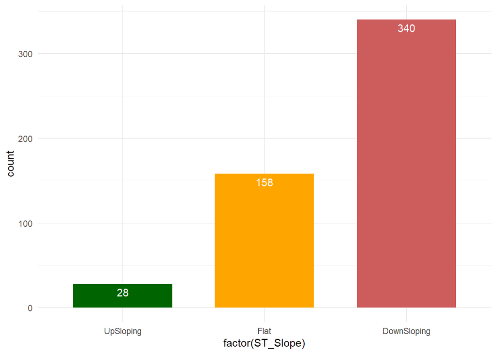

```r
#Checking the ST Slope of Heart Patients
ST_Slope <- format(abnormal$ST.slope)

ggplot(abnormal, aes(x = factor(ST_Slope))) +
  geom_bar(stat = "count", width = 0.7, fill = c("darkgreen", "orange", "indianred")) +
  scale_x_discrete(labels = c('UpSloping', 'Flat', 'DownSloping')) +
  geom_text(aes(label = after_stat(count)), stat = "count", vjust = 1.5, colour = "white") +
  theme_minimal()
```

From the above plot we can observe that about 158 (30%) patients have Flat Slope.

#### Distribution of Cholesterol VS Resting Blood Pressure

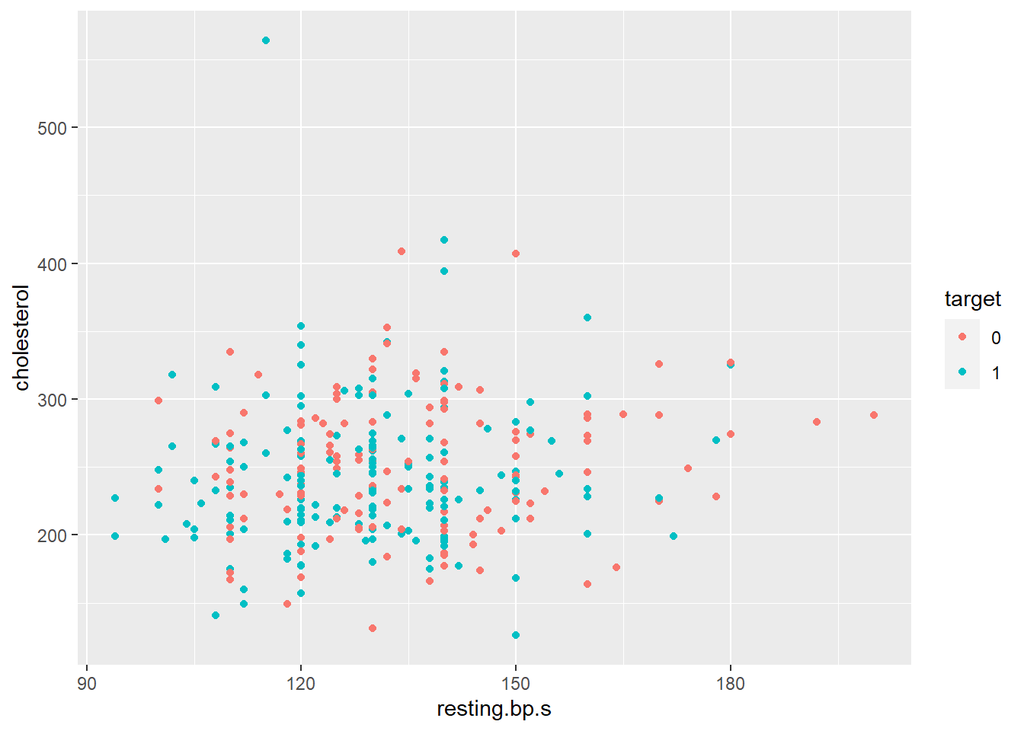

```r
ggplot(heart_disease, aes(x=resting.bp.s, y=cholesterol, color=target)) +
  geom_point()
```

#### Distribution of Age VS Resting Blood Pressure

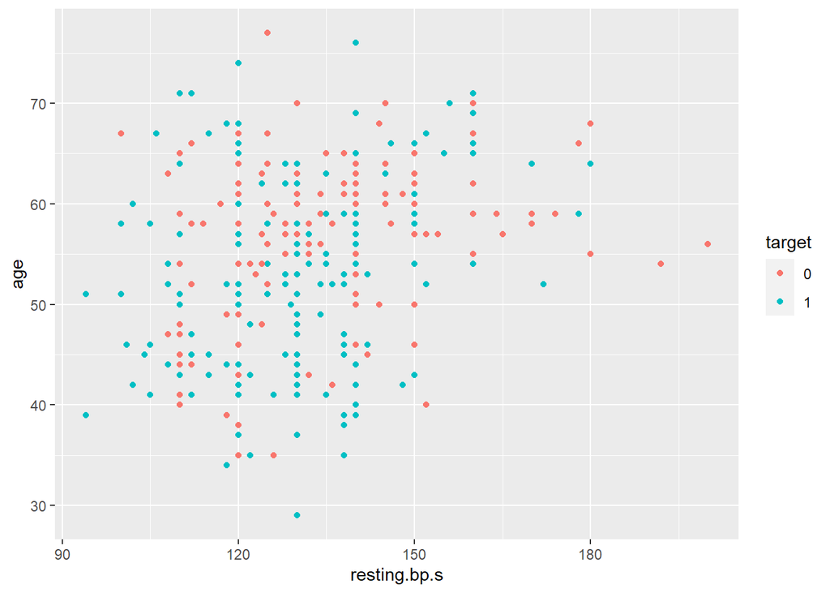

```r
ggplot(heart_disease, aes(x=resting.bp.s, y=age, color=target)) +
  geom_point()
```

**Observation:**

#### Distribution of Age VS Maximum Heart Rate Achieved

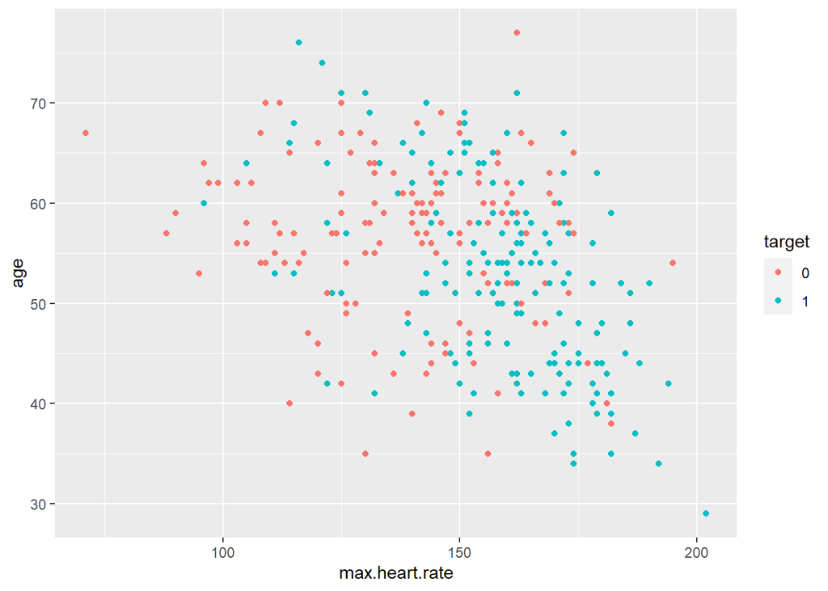

```r
ggplot(heart_disease, aes(x=max.heart.rate, y=age, color=target)) +
  geom_point()
```

**Observation:**

## Model Building

**Test-Train Split**

```r
heart_disease$target <- as.factor(heart_disease$target)
set.seed(100)
TrainingIndex <- createDataPartition(heart_disease$target, p=0.8, list = FALSE)
TrainingSet <- heart_disease[TrainingIndex,] # Training Set
TestingSet <- heart_disease[-TrainingIndex,] # Test Set
```

Checking the dimension of the subset dataset

```r
dim(TrainingSet)
```

```
## [1] 821  12
```

```r
dim(TestingSet)
```

```
## [1] 204  12
```

We can group the features in four different categories: - Physical attributes: *age*; *sex* - General Health: *restingBP*; *Cholesterol*; *FastingBS* - ECG related results: *RestingECG*; *MaxHR*; *Oldpeak*; *ST_Slope*; - Symptomatic: *ChestPainType*; *ExerciseAngina*

## Logistic Regression (glm):

**Base Model**

```r
model1<-glm(target~. , family="binomial", data=TrainingSet)
summary(model1)
```

```
##
## Call:
## glm(formula = target ~ ., family = "binomial", data = TrainingSet)
##
## Deviance Residuals:
##     Min       1Q   Median       3Q      Max
## -2.4912  -0.5646   0.1503   0.6039   2.4735
##
## Coefficients:
##                                    Estimate Std. Error z value Pr(>|z|)
## (Intercept)                        2.612764   1.487936   1.756 0.079094 .
## age                               -0.017536   0.012976  -1.351 0.176571
## sexmale                           -2.142456   0.260410  -8.227  < 2e-16 ***
## Chest.pain.type Atypical Angina    1.293101   0.294556   4.390 1.13e-05 ***
## Chest.pain.type Non-anginal Pain   1.807354   0.254332   7.106 1.19e-12 ***
## Chest.pain.type Asymptomatic       2.064154   0.362019   5.702 1.19e-08 ***
## resting.bp.s                      -0.015259   0.006008  -2.540 0.011088 *
## cholesterol                       -0.004654   0.002050  -2.270 0.023197 *
## fasting.blood.sugar1              -0.125274   0.289461  -0.433 0.665171
## resting.ecg1                       0.277322   0.204402   1.357 0.174861
## resting.ecg2                      -0.413952   1.068236  -0.388 0.698379
## max.heart.rate                     0.022560   0.006061   3.722 0.000197 ***
## exercise.angina1                  -0.803060   0.238809  -3.363 0.000772 ***
## oldpeak                           -0.660053   0.119432  -5.527 3.26e-08 ***
## ST.slope1                         -0.692906   0.468201  -1.480 0.138892
## ST.slope2                         -0.227923   0.504349  -0.452 0.651330
## ---
## Signif. codes:  0 '***' 0.001 '**' 0.01 '*' 0.05 '.' 0.1 ' ' 1
##
## (Dispersion parameter for binomial family taken to be 1)
##
##     Null deviance: 1137.61  on 820  degrees of freedom
## Residual deviance:  660.21  on 805  degrees of freedom
## AIC: 692.21
##
## Number of Fisher Scoring iterations: 5
```

**Interpretation:**

```r
#Multi-collinearity Check
vif(model1)
```

```
##                         GVIF Df GVIF^(1/(2*Df))
## age                 1.360784  1        1.166526
## sex                 1.365039  1        1.168349
## Chest.pain.type     1.482295  3        1.067798
## resting.bp.s        1.176431  1        1.084634
## cholesterol         1.231201  1        1.109595
## fasting.blood.sugar 1.100408  1        1.049003
## resting.ecg         1.152442  2        1.036107
## max.heart.rate      1.500208  1        1.224830
## exercise.angina     1.182459  1        1.087409
## oldpeak             1.506228  1        1.227285
## ST.slope            1.729504  2        1.146781
```

**Interpretation:**

Variance Inflation Factor (VIF) quantifies how much the variance of an estimated regression coefficient increases when predictors are correlated. If no factors are correlated, the VIFs will all be equal to 1. Generally:

- A VIF of 1 indicates that there is no correlation between a given independent variable and any other independent variables in the model.
- A VIF between 1 and 5 suggests moderate correlation, but it’s often considered acceptable.
- A VIF greater than 5 (or sometimes 10, depending on the threshold used in specific fields or studies) might indicate a problematic amount of collinearity.

```r
model2<-glm(target~ age + sex + Chest.pain.type + cholesterol + fasting.blood.sugar +
              max.heart.rate + exercise.angina + oldpeak + ST.slope, family="binomial", data=TrainingSet)
summary(model2)
```

```
##
## Call:
## glm(formula = target ~ age + sex + Chest.pain.type + cholesterol +
##     fasting.blood.sugar + max.heart.rate + exercise.angina +
##     oldpeak + ST.slope, family = "binomial", data = TrainingSet)
##
## Deviance Residuals:
##     Min       1Q   Median       3Q      Max
## -2.5005  -0.5814   0.1812   0.6266   2.5370
##
## Coefficients:
##                                    Estimate Std. Error z value Pr(>|z|)
## (Intercept)                        1.669210   1.367764   1.220 0.222316
## age                               -0.027159   0.012570  -2.161 0.030727 *
## sexmale                           -2.053981   0.250405  -8.203 2.35e-16 ***
## Chest.pain.type Atypical Angina    1.304647   0.292304   4.463 8.07e-06 ***
## Chest.pain.type Non-anginal Pain   1.803797   0.252258   7.151 8.64e-13 ***
## Chest.pain.type Asymptomatic       1.925086   0.360171   5.345 9.05e-08 ***
## cholesterol                       -0.004957   0.001963  -2.525 0.011558 *
## fasting.blood.sugar1              -0.226565   0.283561  -0.799 0.424291
## max.heart.rate                     0.019866   0.005867   3.386 0.000709 ***
## exercise.angina1                  -0.827638   0.235941  -3.508 0.000452 ***
## oldpeak                           -0.673508   0.115849  -5.814 6.11e-09 ***
## ST.slope1                         -0.631441   0.447924  -1.410 0.158627
## ST.slope2                         -0.142312   0.481773  -0.295 0.767694
## ---
## Signif. codes:  0 '***' 0.001 '**' 0.01 '*' 0.05 '.' 0.1 ' ' 1
##
## (Dispersion parameter for binomial family taken to be 1)
##
##     Null deviance: 1137.61  on 820  degrees of freedom
## Residual deviance:  669.34  on 808  degrees of freedom
## AIC: 695.34
##
## Number of Fisher Scoring iterations: 5
```

**Interpretation:**

The logistic regression model predicts target variables using predictor variables like age, sex, chest pain type, cholesterol, fasting blood sugar, max heart rate, exercise angina, oldpeak, and ST slope.

The intercept represents the log-odds of an event when all predictor variables are zero. The coefficients for individual predictors are interpreted as follows: age (age) is associated with a decrease of approximately 0.027 in the log-odds, while being male is linked to a decrease of about 2.054 in log-odds compared to being female. There are three types of chest pain: atypical, non-anginal, and asymptomatic. Cholesterol is associated with a decrease of approximately 0.005 in log-odds, while fasting blood sugar is linked to a non-significant decrease. Max heart rate is associated with a significant increase of approximately 0.020 in log-odds, while exercise-induced angina is linked to a decrease of about 0.828 in log-odds. Oldpeak is associated with a decrease of approximately 0.674 in log-odds. ST slope is associated with a non-significant decrease of approximately 0.631 in log-odds and a non-significant decrease of approximately 0.142 in log-odds.

```r
model3<-glm(target~ age + sex + Chest.pain.type + cholesterol + fasting.blood.sugar +
              max.heart.rate + exercise.angina + oldpeak + ST.slope +
              max.heart.rate * Chest.pain.type , family="binomial", data=TrainingSet)
summary(model3)
```

```
##
## Call:
## glm(formula = target ~ age + sex + Chest.pain.type + cholesterol +
##     fasting.blood.sugar + max.heart.rate + exercise.angina +
##     oldpeak + ST.slope + max.heart.rate * Chest.pain.type, family = "binomial",
##     data = TrainingSet)
##
## Deviance Residuals:
##     Min       1Q   Median       3Q      Max
## -2.4877  -0.5577   0.1350   0.6435   2.5858
##
## Coefficients:
##                                                    Estimate Std. Error z value
## (Intercept)                                       3.284e+00  1.540e+00   2.133
## age                                              -2.656e-02  1.282e-02  -2.072
## sexmale                                          -2.179e+00  2.567e-01  -8.488
## Chest.pain.type Atypical Angina                   1.366e+00  2.242e+00   0.609
## Chest.pain.type Non-anginal Pain                 -3.902e+00  1.859e+00  -2.099
## Chest.pain.type Asymptomatic                      1.458e+00  2.759e+00   0.528
## cholesterol                                      -5.504e-03  2.010e-03  -2.739
## fasting.blood.sugar1                             -2.371e-01  2.901e-01  -0.817
## max.heart.rate                                    1.022e-02  7.542e-03   1.355
## exercise.angina1                                 -8.759e-01  2.399e-01  -3.651
## oldpeak                                          -7.098e-01  1.199e-01  -5.922
## ST.slope1                                        -5.800e-01  4.646e-01  -1.248
## ST.slope2                                        -6.369e-02  4.933e-01  -0.129
## Chest.pain.type Atypical Angina :max.heart.rate   6.474e-05  1.417e-02   0.005
## Chest.pain.type Non-anginal Pain :max.heart.rate  3.834e-02  1.248e-02   3.072
## Chest.pain.type Asymptomatic :max.heart.rate      3.782e-03  1.764e-02   0.214
##                                                  Pr(>|z|)
## (Intercept)                                      0.032955 *
## age                                              0.038302 *
## sexmale                                           < 2e-16 ***
## Chest.pain.type Atypical Angina                  0.542199
## Chest.pain.type Non-anginal Pain                 0.035777 *
## Chest.pain.type Asymptomatic                     0.597191
## cholesterol                                      0.006169 **
## fasting.blood.sugar1                             0.413873
## max.heart.rate                                   0.175359
## exercise.angina1                                 0.000261 ***
## oldpeak                                          3.19e-09 ***
## ST.slope1                                        0.211893
## ST.slope2                                        0.897281
## Chest.pain.type Atypical Angina :max.heart.rate  0.996354
## Chest.pain.type Non-anginal Pain :max.heart.rate 0.002126 **
## Chest.pain.type Asymptomatic :max.heart.rate     0.830287
## ---
## Signif. codes:  0 '***' 0.001 '**' 0.01 '*' 0.05 '.' 0.1 ' ' 1
##
## (Dispersion parameter for binomial family taken to be 1)
##
##     Null deviance: 1137.61  on 820  degrees of freedom
## Residual deviance:  658.69  on 805  degrees of freedom
## AIC: 690.69
##
## Number of Fisher Scoring iterations: 5
```

**Interpretation:**

The logistic regression model predicts various factors such as age, sex, chest pain type, cholesterol, fasting blood sugar, max heart rate, exercise angina, oldpeak, and certain interactions. For each one-unit increase in age, the log-odds of the target variable decrease by approximately 0.02656, holding other variables constant. Being male is associated with a decrease of approximately 2.179 in the log-odds of the target variable compared to being female. Chest pain type (Atypical Angina, Non-anginal Pain, Asymptomatic) represents changes in log-odds for the respective Chest.pain.type levels compared to Typical Angina. Cholesterol (-0.005504) decreases the log-odds of the target variable by approximately 0.005504, holding other variables constant. Fasting blood sugar level (-0.2371) decreases the log-odds of the target by approximately 0.2371. Maximum heart rate (0.01022) corresponds to an increase of about 0.01022 in log-odds. Exercise-induced angina is linked to a decrease of about 0.8759 in log-odds compared to absence. Oldpeak (-0.7098) decreases the log-odds of the target variable by around 0.7098. ST.slope1 (-0.5800) and ST.slope2 (-0.06369) indicate changes in log-odds compared to the reference level. Interaction terms show additional effects on log-odds with interactions between max.heart.rate and Chest.pain.type.

Significance codes indicate the level of significance for each variable. The model fits well based on deviance, AIC, and significance levels. Log-odds provide a way to understand the relationship between predictors and the likelihood of the target variable, but their interpretation might require further consideration and context.

```r
model4<-glm(target~ age + sex + Chest.pain.type + cholesterol + fasting.blood.sugar +
              max.heart.rate + exercise.angina + oldpeak + ST.slope +
              max.heart.rate * Chest.pain.type + ST.slope * oldpeak , family="binomial", data=TrainingSet)
summary(model4)
```

```
##
## Call:
## glm(formula = target ~ age + sex + Chest.pain.type + cholesterol +
##     fasting.blood.sugar + max.heart.rate + exercise.angina +
##     oldpeak + ST.slope + max.heart.rate * Chest.pain.type + ST.slope *
##     oldpeak, family = "binomial", data = TrainingSet)
##
## Deviance Residuals:
##     Min       1Q   Median       3Q      Max
## -2.6087  -0.5410   0.1393   0.6425   2.7321
##
## Coefficients:
##                                                    Estimate Std. Error z value
## (Intercept)                                       3.1131448  1.6568392   1.879
## age                                              -0.0276776  0.0129875  -2.131
## sexmale                                          -2.1639209  0.2613449  -8.280
## Chest.pain.type Atypical Angina                   1.2712552  2.2617705   0.562
## Chest.pain.type Non-anginal Pain                 -3.4272504  1.8599094  -1.843
## Chest.pain.type Asymptomatic                      1.6095635  2.8273910   0.569
## cholesterol                                      -0.0052228  0.0020264  -2.577
## fasting.blood.sugar1                             -0.2057523  0.2903516  -0.709
## max.heart.rate                                    0.0110248  0.0076115   1.448
## exercise.angina1                                 -0.8939651  0.2411888  -3.706
## oldpeak                                          -0.6922800  0.2699370  -2.565
## ST.slope1                                        -0.2581713  0.8083620  -0.319
## ST.slope2                                        -0.1890845  0.7740317  -0.244
## Chest.pain.type Atypical Angina :max.heart.rate   0.0007721  0.0143074   0.054
## Chest.pain.type Non-anginal Pain :max.heart.rate  0.0348899  0.0124688   2.798
## Chest.pain.type Asymptomatic :max.heart.rate      0.0026352  0.0181663   0.145
## oldpeak:ST.slope1                                -0.2426472  0.3214770  -0.755
## oldpeak:ST.slope2                                 0.3621604  0.3419853   1.059
##                                                  Pr(>|z|)
## (Intercept)                                       0.06025 .
## age                                               0.03308 *
## sexmale                                           < 2e-16 ***
## Chest.pain.type Atypical Angina                   0.57407
## Chest.pain.type Non-anginal Pain                  0.06537 .
## Chest.pain.type Asymptomatic                      0.56917
## cholesterol                                       0.00995 **
## fasting.blood.sugar1                              0.47855
## max.heart.rate                                    0.14749
## exercise.angina1                                  0.00021 ***
## oldpeak                                           0.01033 *
## ST.slope1                                         0.74944
## ST.slope2                                         0.80701
## Chest.pain.type Atypical Angina :max.heart.rate   0.95696
## Chest.pain.type Non-anginal Pain :max.heart.rate  0.00514 **
## Chest.pain.type Asymptomatic :max.heart.rate      0.88466
## oldpeak:ST.slope1                                 0.45038
## oldpeak:ST.slope2                                 0.28960
## ---
## Signif. codes:  0 '***' 0.001 '**' 0.01 '*' 0.05 '.' 0.1 ' ' 1
##
## (Dispersion parameter for binomial family taken to be 1)
##
##     Null deviance: 1137.61  on 820  degrees of freedom
## Residual deviance:  653.68  on 803  degrees of freedom
## AIC: 689.68
##
## Number of Fisher Scoring iterations: 5
```

**Interpretation:**

The p-value is a statistical measure used to evaluate the evidence against a null hypothesis. In logistic regression, a p-value less than 0.05 indicates the coefficient is likely different from zero, rejecting the null hypothesis. A p-value greater than 0.05 indicates insufficient evidence to reject the null hypothesis, suggesting the predictor may not have a statistically significant impact on the response variable.

## Prediction

we select model 4 based on the best AIC

```r
predicted_probs <- predict(model4, newdata = TestingSet, type = "response")
```

```r
predicted_classes <- ifelse(predicted_probs > 0.5, 1, 0)
```

```r
confusionMatrix(as.factor(predicted_classes), as.factor(TestingSet$target))
```

```
## Confusion Matrix and Statistics
##
##           Reference
## Prediction  0  1
##          0 87 15
##          1 12 90
##
##                Accuracy : 0.8676
##                  95% CI : (0.8133, 0.9109)
##     No Information Rate : 0.5147
##     P-Value [Acc > NIR] : <2e-16
##
##                   Kappa : 0.7353
##
##  Mcnemar's Test P-Value : 0.7003
##
##             Sensitivity : 0.8788
##             Specificity : 0.8571
##          Pos Pred Value : 0.8529
##          Neg Pred Value : 0.8824
##              Prevalence : 0.4853
##          Detection Rate : 0.4265
##    Detection Prevalence : 0.5000
##       Balanced Accuracy : 0.8680
##
##        'Positive' Class : 0
##
```

**Interpretation:**

**Confusion Matrix:**

**True Negative (TN):** 87 observations were correctly predicted as class 0.

**True Positive (TP):** 90 observations were correctly predicted as class 1.

**Accuracy:** This metric represents the proportion of correct predictions out of the total predictions. The model’s accuracy is 0.8676, or 86.76%. This means the model made correct predictions for 86.76% of the samples in the dataset.

**95% CI:** The 95% confidence interval for the accuracy is (0.8133, 0.9109). This means we are 95% confident that the model’s true accuracy lies within this interval.

**No Information Rate (NIR):** This is the accuracy that could be achieved by always predicting the most frequent class. The NIR is 0.5147, which indicates that 51.47% of the samples belong to the most frequent class.

**P-Value [Acc > NIR]:** The p-value tests the hypothesis that the model’s accuracy is no better than the NIR. A very low p-value (here, <2e-16) suggests that the model is significantly better than just guessing based on the most frequent class.

**Kappa:** This statistic measures the agreement between the predicted and actual classifications, corrected for what would be expected by chance. A kappa of 1 indicates perfect agreement, while a kappa of 0 indicates agreement equivalent to chance. A value of 0.7353 suggests good agreement.

**Mcnemar’s Test P-Value:** This tests the null hypothesis that the row and column marginal frequencies are equal (i.e., FP = FN). A p-value greater than 0.05 (here, 0.7003) suggests that there isn’t a significant difference between the numbers of false positives and false negatives.

**Sensitivity (or Recall):** Of all the actual positive instances, how many did we correctly predict? The model’s sensitivity is 0.8788 or 87.88%.

**Specificity:** Of all the actual negative instances, how many did we correctly predict? The model’s specificity is 0.8571 or 85.71%.

**Positive Predictive Value (PPV, or Precision):** Of all the predicted positives, how many were actual positives? The PPV is 0.8529 or 85.29%.

**Negative Predictive Value (NPV):** Of all the predicted negatives, how many were actual negatives? The NPV is 0.8824 or 88.24%.

**Prevalence:** This shows how often the positive condition actually occurs in our sample. The prevalence here is 0.4853 or 48.53%.

**Detection Rate:** This is the rate at which we detect the positive condition, calculated as the number of true positives divided by the total number of samples. Here, it’s 0.4265 or 42.65%.

**Detection Prevalence:** The proportion of predicted positives from all samples is 0.5000 or 50%.

**Balanced Accuracy:** This is the average of sensitivity and specificity, which provides a balanced view of the model’s performance across both classes. It’s 0.8680 or 86.80%.

Lastly, the ‘Positive’ Class being defined as 0 means that the metrics provided (like Sensitivity, Specificity, etc.) are based on class 0 being considered as the ‘positive’ class in this binary classification context.

## Logistic Lasso Regression (glmnet):

We continue our analysis with linear regression models with a Lasso. This model will be particularly relevant for us, since it will show the degree of influence of the predictors.

```r
lasso_heart_disease <- read.csv("C:/Users/khush/OneDrive/Desktop/RProject - KW/heart_disease/heart_statlog_cleveland_hungary.csv")
```

In the following code the “target” variable in the “lasso_heart_disease” dataset to a numeric type and assigns it back to the “target” column. This can be useful when the “target” variable is originally stored as a different data type, and you want to ensure it is treated as numeric.

```r
# Fit Lasso regression with cross-validation
lasso_heart_disease$target <- as.numeric(lasso_heart_disease$target)
str(lasso_heart_disease)
```

```
## 'data.frame':    1025 obs. of  12 variables:
##  $ age                : int  52 53 70 61 62 58 58 55 46 54 ...
##  $ sex                : int  1 1 1 1 0 0 1 1 1 1 ...
##  $ Chest.pain.type    : int  0 0 0 0 0 0 0 0 0 0 ...
##  $ resting.bp.s       : int  125 140 145 148 138 100 114 160 120 122 ...
##  $ cholesterol        : int  212 203 174 203 294 248 318 289 249 286 ...
##  $ fasting.blood.sugar: int  0 1 0 0 1 0 0 0 0 0 ...
##  $ resting.ecg        : int  1 0 1 1 1 0 2 0 0 0 ...
##  $ max.heart.rate     : int  168 155 125 161 106 122 140 145 144 116 ...
##  $ exercise.angina    : int  0 1 1 0 0 0 0 1 0 1 ...
##  $ oldpeak            : num  1 3.1 2.6 0 1.9 1 4.4 0.8 0.8 3.2 ...
##  $ ST.slope           : int  2 0 0 2 1 1 0 1 2 1 ...
##  $ target             : num  0 0 0 0 0 1 0 0 0 0 ...
```

The following code particularly useful when dealing with categorical variables represented by numeric codes, and you want to convert them to more meaningful factor levels. In this case, it transforms the “sex” variable from numeric (0, 1) to a factor with levels “female” and “male.”

```r
lasso_heart_disease$sex<-factor(lasso_heart_disease$sex,levels =c(0,1),labels = c("female","male"))
str(lasso_heart_disease)
```

```
## 'data.frame':    1025 obs. of  12 variables:
##  $ age                : int  52 53 70 61 62 58 58 55 46 54 ...
##  $ sex                : Factor w/ 2 levels "female","male": 2 2 2 2 1 1 2 2 2 2 ...
##  $ Chest.pain.type    : int  0 0 0 0 0 0 0 0 0 0 ...
##  $ resting.bp.s       : int  125 140 145 148 138 100 114 160 120 122 ...
##  $ cholesterol        : int  212 203 174 203 294 248 318 289 249 286 ...
##  $ fasting.blood.sugar: int  0 1 0 0 1 0 0 0 0 0 ...
##  $ resting.ecg        : int  1 0 1 1 1 0 2 0 0 0 ...
##  $ max.heart.rate     : int  168 155 125 161 106 122 140 145 144 116 ...
##  $ exercise.angina    : int  0 1 1 0 0 0 0 1 0 1 ...
##  $ oldpeak            : num  1 3.1 2.6 0 1.9 1 4.4 0.8 0.8 3.2 ...
##  $ ST.slope           : int  2 0 0 2 1 1 0 1 2 1 ...
##  $ target             : num  0 0 0 0 0 1 0 0 0 0 ...
```

Following code is Converting the “fasting.blood.sugar” variable to a factor,the “fasting.blood.sugar” variable is a factor with levels “0” and “1,” indicating the absence or presence of fasting blood sugar, respectively.

```r
lasso_heart_disease$fasting.blood.sugar<-as.factor(lasso_heart_disease$fasting.blood.sugar)
str(lasso_heart_disease)
```

```
## 'data.frame':    1025 obs. of  12 variables:
##  $ age                : int  52 53 70 61 62 58 58 55 46 54 ...
##  $ sex                : Factor w/ 2 levels "female","male": 2 2 2 2 1 1 2 2 2 2 ...
##  $ Chest.pain.type    : int  0 0 0 0 0 0 0 0 0 0 ...
##  $ resting.bp.s       : int  125 140 145 148 138 100 114 160 120 122 ...
##  $ cholesterol        : int  212 203 174 203 294 248 318 289 249 286 ...
##  $ fasting.blood.sugar: Factor w/ 2 levels "0","1": 1 2 1 1 2 1 1 1 1 1 ...
##  $ resting.ecg        : int  1 0 1 1 1 0 2 0 0 0 ...
##  $ max.heart.rate     : int  168 155 125 161 106 122 140 145 144 116 ...
##  $ exercise.angina    : int  0 1 1 0 0 0 0 1 0 1 ...
##  $ oldpeak            : num  1 3.1 2.6 0 1.9 1 4.4 0.8 0.8 3.2 ...
##  $ ST.slope           : int  2 0 0 2 1 1 0 1 2 1 ...
##  $ target             : num  0 0 0 0 0 1 0 0 0 0 ...
```

Following code shows conversion of the “Chest.pain.type” variable to a factor the “Chest.pain.type” variable is a factor with levels “Typical Angina,” “Atypical Angina,” “Non-anginal Pain,” and “Asymptomatic,” reflecting the different categories of chest pain.

```r
lasso_heart_disease$Chest.pain.type<-as.factor(lasso_heart_disease$Chest.pain.type)
# Define the labels for the levels
chest_pain_labels <- c(' Typical Angina ', ' Atypical Angina ', ' Non-anginal Pain ', ' Asymptomatic ')

# Set the levels of the factor variable
levels(lasso_heart_disease$Chest.pain.type) <- chest_pain_labels


str(lasso_heart_disease)
```

```
## 'data.frame':    1025 obs. of  12 variables:
##  $ age                : int  52 53 70 61 62 58 58 55 46 54 ...
##  $ sex                : Factor w/ 2 levels "female","male": 2 2 2 2 1 1 2 2 2 2 ...
##  $ Chest.pain.type    : Factor w/ 4 levels " Typical Angina ",..: 1 1 1 1 1 1 1 1 1 1 ...
##  $ resting.bp.s       : int  125 140 145 148 138 100 114 160 120 122 ...
##  $ cholesterol        : int  212 203 174 203 294 248 318 289 249 286 ...
##  $ fasting.blood.sugar: Factor w/ 2 levels "0","1": 1 2 1 1 2 1 1 1 1 1 ...
##  $ resting.ecg        : int  1 0 1 1 1 0 2 0 0 0 ...
##  $ max.heart.rate     : int  168 155 125 161 106 122 140 145 144 116 ...
##  $ exercise.angina    : int  0 1 1 0 0 0 0 1 0 1 ...
##  $ oldpeak            : num  1 3.1 2.6 0 1.9 1 4.4 0.8 0.8 3.2 ...
##  $ ST.slope           : int  2 0 0 2 1 1 0 1 2 1 ...
##  $ target             : num  0 0 0 0 0 1 0 0 0 0 ...
```

Converting the “resting.ecg” variable to a factor,the “resting.ecg” variable is a factor with levels “0,” “1,” and “2.”

```r
lasso_heart_disease$resting.ecg<-as.factor(lasso_heart_disease$resting.ecg )
str(lasso_heart_disease)
```

```
## 'data.frame':    1025 obs. of  12 variables:
##  $ age                : int  52 53 70 61 62 58 58 55 46 54 ...
##  $ sex                : Factor w/ 2 levels "female","male": 2 2 2 2 1 1 2 2 2 2 ...
##  $ Chest.pain.type    : Factor w/ 4 levels " Typical Angina ",..: 1 1 1 1 1 1 1 1 1 1 ...
##  $ resting.bp.s       : int  125 140 145 148 138 100 114 160 120 122 ...
##  $ cholesterol        : int  212 203 174 203 294 248 318 289 249 286 ...
##  $ fasting.blood.sugar: Factor w/ 2 levels "0","1": 1 2 1 1 2 1 1 1 1 1 ...
##  $ resting.ecg        : Factor w/ 3 levels "0","1","2": 2 1 2 2 2 1 3 1 1 1 ...
##  $ max.heart.rate     : int  168 155 125 161 106 122 140 145 144 116 ...
##  $ exercise.angina    : int  0 1 1 0 0 0 0 1 0 1 ...
##  $ oldpeak            : num  1 3.1 2.6 0 1.9 1 4.4 0.8 0.8 3.2 ...
##  $ ST.slope           : int  2 0 0 2 1 1 0 1 2 1 ...
##  $ target             : num  0 0 0 0 0 1 0 0 0 0 ...
```

Converting the “exercise.angina” variable to a factor,“exercise.angina” variable is a factor with levels “0” and “1.”

```r
lasso_heart_disease$exercise.angina<-as.factor(lasso_heart_disease$exercise.angina)
str(lasso_heart_disease)
```

```
## 'data.frame':    1025 obs. of  12 variables:
##  $ age                : int  52 53 70 61 62 58 58 55 46 54 ...
##  $ sex                : Factor w/ 2 levels "female","male": 2 2 2 2 1 1 2 2 2 2 ...
##  $ Chest.pain.type    : Factor w/ 4 levels " Typical Angina ",..: 1 1 1 1 1 1 1 1 1 1 ...
##  $ resting.bp.s       : int  125 140 145 148 138 100 114 160 120 122 ...
##  $ cholesterol        : int  212 203 174 203 294 248 318 289 249 286 ...
##  $ fasting.blood.sugar: Factor w/ 2 levels "0","1": 1 2 1 1 2 1 1 1 1 1 ...
##  $ resting.ecg        : Factor w/ 3 levels "0","1","2": 2 1 2 2 2 1 3 1 1 1 ...
##  $ max.heart.rate     : int  168 155 125 161 106 122 140 145 144 116 ...
##  $ exercise.angina    : Factor w/ 2 levels "0","1": 1 2 2 1 1 1 1 2 1 2 ...
##  $ oldpeak            : num  1 3.1 2.6 0 1.9 1 4.4 0.8 0.8 3.2 ...
##  $ ST.slope           : int  2 0 0 2 1 1 0 1 2 1 ...
##  $ target             : num  0 0 0 0 0 1 0 0 0 0 ...
```

Converting the “ST.slope” variable to a factor, “ST.slope” variable is a factor with levels “0,” “1,” and “2.”

```r
lasso_heart_disease$ST.slope<-as.factor(lasso_heart_disease$ST.slope)
str(lasso_heart_disease)
```

```
## 'data.frame':    1025 obs. of  12 variables:
##  $ age                : int  52 53 70 61 62 58 58 55 46 54 ...
##  $ sex                : Factor w/ 2 levels "female","male": 2 2 2 2 1 1 2 2 2 2 ...
##  $ Chest.pain.type    : Factor w/ 4 levels " Typical Angina ",..: 1 1 1 1 1 1 1 1 1 1 ...
##  $ resting.bp.s       : int  125 140 145 148 138 100 114 160 120 122 ...
##  $ cholesterol        : int  212 203 174 203 294 248 318 289 249 286 ...
##  $ fasting.blood.sugar: Factor w/ 2 levels "0","1": 1 2 1 1 2 1 1 1 1 1 ...
##  $ resting.ecg        : Factor w/ 3 levels "0","1","2": 2 1 2 2 2 1 3 1 1 1 ...
##  $ max.heart.rate     : int  168 155 125 161 106 122 140 145 144 116 ...
##  $ exercise.angina    : Factor w/ 2 levels "0","1": 1 2 2 1 1 1 1 2 1 2 ...
##  $ oldpeak            : num  1 3.1 2.6 0 1.9 1 4.4 0.8 0.8 3.2 ...
##  $ ST.slope           : Factor w/ 3 levels "0","1","2": 3 1 1 3 2 2 1 2 3 2 ...
##  $ target             : num  0 0 0 0 0 1 0 0 0 0 ...
```

Converting the “target” variable to a factor, “target” variable is a factor with levels “0” and “1.”

```r
lasso_heart_disease$target<-as.factor(lasso_heart_disease$target)
str(lasso_heart_disease)
```

```
## 'data.frame':    1025 obs. of  12 variables:
##  $ age                : int  52 53 70 61 62 58 58 55 46 54 ...
##  $ sex                : Factor w/ 2 levels "female","male": 2 2 2 2 1 1 2 2 2 2 ...
##  $ Chest.pain.type    : Factor w/ 4 levels " Typical Angina ",..: 1 1 1 1 1 1 1 1 1 1 ...
##  $ resting.bp.s       : int  125 140 145 148 138 100 114 160 120 122 ...
##  $ cholesterol        : int  212 203 174 203 294 248 318 289 249 286 ...
##  $ fasting.blood.sugar: Factor w/ 2 levels "0","1": 1 2 1 1 2 1 1 1 1 1 ...
##  $ resting.ecg        : Factor w/ 3 levels "0","1","2": 2 1 2 2 2 1 3 1 1 1 ...
##  $ max.heart.rate     : int  168 155 125 161 106 122 140 145 144 116 ...
##  $ exercise.angina    : Factor w/ 2 levels "0","1": 1 2 2 1 1 1 1 2 1 2 ...
##  $ oldpeak            : num  1 3.1 2.6 0 1.9 1 4.4 0.8 0.8 3.2 ...
##  $ ST.slope           : Factor w/ 3 levels "0","1","2": 3 1 1 3 2 2 1 2 3 2 ...
##  $ target             : Factor w/ 2 levels "0","1": 1 1 1 1 1 2 1 1 1 1 ...
```

```r
# Assuming binary variables are encoded as 0/1
lasso_heart_disease$sex <- as.numeric(lasso_heart_disease$sex) - 1
lasso_heart_disease$fasting.blood.sugar <- as.numeric(lasso_heart_disease$fasting.blood.sugar) - 1

lasso_heart_disease[, -c(1, 13)] <- lapply(lasso_heart_disease[, -c(1, 13)], as.numeric)

# Run LASSO regression
x <- as.matrix(lasso_heart_disease[, -12])  # excluding the target variable
y <- as.numeric(lasso_heart_disease$target) - 1
cv_model <- cv.glmnet(x, y, alpha = 1, family = "binomial")
```

**Interpretation:**

All columns (excluding the first and last columns) of the “lasso_heart_disease” data frame are converted to numeric type using lapply and as.numeric.The LASSO regression is run using the cv.glmnet function. The independent variables (features) are stored in the matrix x, excluding the target variable. The dependent variable (response) is stored in the vector y. The LASSO regression is performed with L1 regularization (alpha = 1) and using the binomial family.

```r
#find the optimal lambda
best_lambda <- cv_model$lambda.min
best_lambda
```

```
## [1] 0.00251963
```

## Logistic Ridge Regression

```r
#cross validation
cv_fit <- cv.glmnet(x,y, alpha = 0, family = "binomial")
```

```r
#find the optimal lambda
best_lambda <- cv_fit$lambda.min
best_lambda
```

```
## [1] 0.02191446
```

```r
ridge_model <- glmnet(x, y, alpha = 0, family = binomial)
```

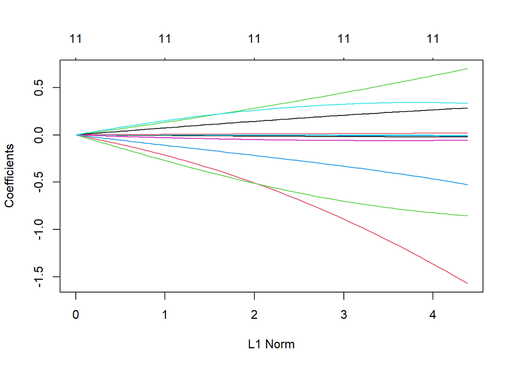

```r
plot(ridge_model)
```

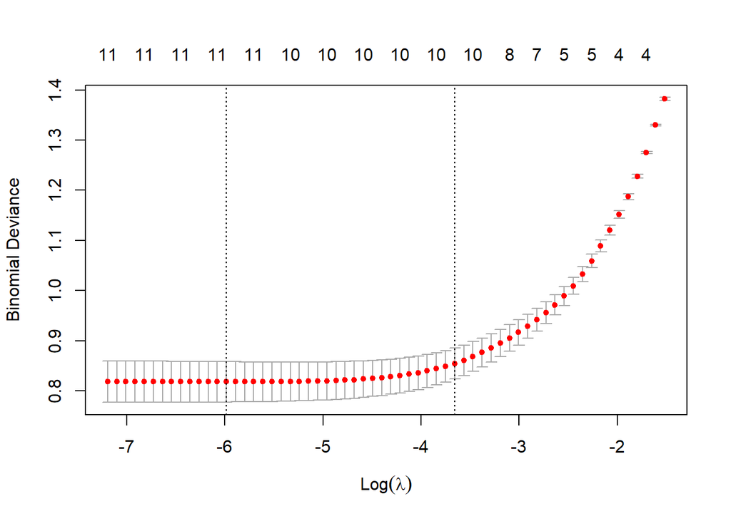

```r
plot(cv_model)
```

```r
#find the coefficients of best model
best_ridge_model <- glmnet(x,y, alpha = 0, family = binomial , lambda = best_lambda)
coef(best_ridge_model)
```

```
## 12 x 1 sparse Matrix of class "dgCMatrix"
##                               s0
## (Intercept)          1.165985378
## age                 -0.023168801
## sex                 -1.569899440
## Chest.pain.type      0.700025282
## resting.bp.s        -0.012653037
## cholesterol         -0.003917195
## fasting.blood.sugar -0.057797433
## resting.ecg          0.284826945
## max.heart.rate       0.019632304
## exercise.angina     -0.853866256
## oldpeak             -0.524786018
## ST.slope             0.334238697
```

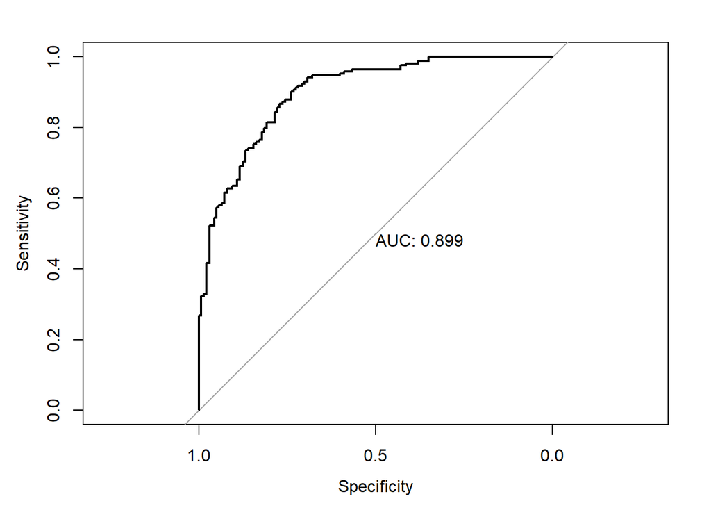

```r
ridge_predictions <- predict(best_ridge_model, newx = x, s = best_lambda, type = "response")
glm.roc <- roc(heart_disease$target, ridge_predictions, plot = TRUE, print.auc = TRUE)
```

**Interpretation:** The AUC for the logistic Ridge regression is 0.89.

## LDA - Linear Discriminant Analysis

```r
lda.model <- lda(target ~ age + sex + Chest.pain.type + resting.bp.s + cholesterol +
                 fasting.blood.sugar + resting.ecg + max.heart.rate + exercise.angina +
                 oldpeak + ST.slope, data = heart_disease)
```

```r
# Print the model summary
print(lda.model)
```

```
## Call:
## lda(target ~ age + sex + Chest.pain.type + resting.bp.s + cholesterol +
##     fasting.blood.sugar + resting.ecg + max.heart.rate + exercise.angina +
##     oldpeak + ST.slope, data = heart_disease)
##
## Prior probabilities of groups:
##         0         1
## 0.4868293 0.5131707
##
## Group means:
##        age   sexmale Chest.pain.type Atypical Angina
## 0 56.56914 0.8276553                       0.06613226
## 1 52.40875 0.5703422                       0.25475285
##   Chest.pain.type Non-anginal Pain  Chest.pain.type Asymptomatic  resting.bp.s
## 0                         0.1302605                    0.05210421     134.1062
## 1                         0.4163498                    0.09695817     129.2452
##   cholesterol fasting.blood.sugar1 resting.ecg1 resting.ecg2 max.heart.rate
## 0    251.2926            0.1643287    0.4088176  0.024048096       139.1303
## 1    240.9791            0.1349810    0.5874525  0.005703422       158.5856
##   exercise.angina1  oldpeak ST.slope1 ST.slope2
## 0        0.5490982 1.600200 0.6492986 0.2585170
## 1        0.1349810 0.569962 0.3003802 0.6463878
##
## Coefficients of linear discriminants:
##                                            LD1
## age                               -0.013707229
## sexmale                           -1.081311883
## Chest.pain.type Atypical Angina    1.024529443
## Chest.pain.type Non-anginal Pain   1.232943121
## Chest.pain.type Asymptomatic       1.423209009
## resting.bp.s                      -0.007906018
## cholesterol                       -0.002438583
## fasting.blood.sugar1              -0.137388463
## resting.ecg1                       0.166099632
## resting.ecg2                      -0.097701904
## max.heart.rate                     0.008654801
## exercise.angina1                  -0.473022003
## oldpeak                           -0.332218953
## ST.slope1                         -0.666905379
## ST.slope2                         -0.125791983
```

```r
# To predict on new data using the fitted model
predictions <- predict(lda.model, newdata=heart_disease)
head(predictions$class)
```

```
## [1] 0 0 0 0 0 0
## Levels: 0 1
```

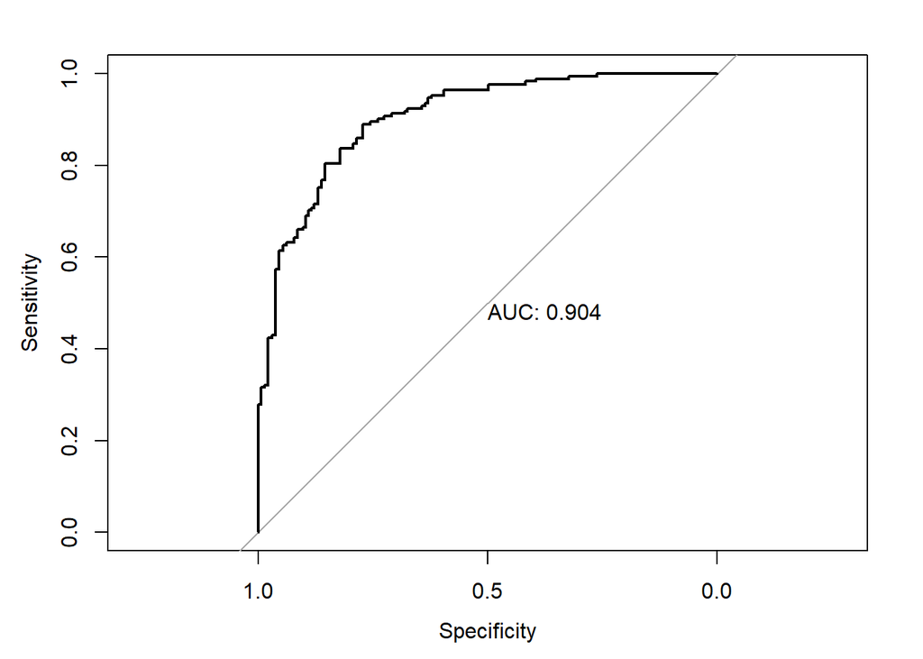

```r
glm.roc <- roc(heart_disease$target, predictions$posterior[, "1"], plot = TRUE, print.auc = TRUE)
```

**Interpretation:** The AUC for the LDA is 0.90.

The goal of LDA is to project the predictors (in this case, factors related to heart disease) onto a lower-dimensional space in such a way that the two categories of the response variable (target) are as separated as possible.

**Prior probabilities of groups:**

This displays the proportions of each class in the response variable target. There are two classes: 0 and 1. About 48.68% of the observations fall into class 0 and 51.31% into class 1. This means that the dataset is balanced between the two categories.

**Group means:**

**Coefficients of linear discriminants:**

The coefficients indicate the direction and magnitude of the effect of each predictor on the discriminant function. The discriminant function is a linear combination of the predictors that provides the best separation between the classes.

Overall, the LDA model provides a linear combination of the predictors to maximize the separation between the two classes in the target variable. Using this model, you can project new observations into this discriminative space to classify them as either 0 or 1 based on which group mean they are closer to in the discriminative space.

## What is AUC value?

AUC, or “Area Under the Curve,” is a metric used to assess the performance of a binary classification model, derived from the ROC curve, which represents the trade-off between true positive rate (sensitivity) and false positive rate (1-specificity) at different thresholds.

In the context of AUC:

1] True Positive Rate (Sensitivity): It is the proportion of actual positive instances correctly predicted as positive by the model.

2] False Positive Rate (1 - Specificity): It is the proportion of actual negative instances incorrectly predicted as positive by the model.

AUC values range from 0 to 1, where:

AUC = 0.5 suggests no discrimination (random guessing). AUC < 0.5 suggests the model performs worse than random. AUC > 0.5 suggests better-than-random performance, with higher values indicating better discrimination.

A model with a higher AUC is considered better at distinguishing between classes.